Boats Segmentation: Cluster Analysis

**Mastaks**

## Our Approach

1. Confirm the data in metric
2. Decide whether to scale or standardize the data
3. Decide which variables to use for clustering
4. Define similarity or dissimilarity measures between observations
5. Visualize Individual Attributes and Pair-wise Distances between the Observations
6. Select the clustering method to use and decide how many clusters to have
7. Profile and interpret the clusters
8. Assess the robustness of our clusters

Let's follow these steps.

#### 2. Decide whether to scale or standardize the data

```r
ProjectData_scaled = apply(ProjectData, 2, function(r) {
    if (sd(r) != 0)
        res = (r - mean(r))/sd(r) else res = 0 * r
    res
})
```

While this is typically a necessary step, one has to always do it with care: some times you may want your analytics findings to be driven mainly by a few attributes that take large values; other times having attributes with different scales may imply something about those attributes. In many such cases one may choose to skip step 2 for some of the raw attributes.

We decide to use the unscaled data for now.

#### Step 3. Decide which variables to use for clustering

The first 29 questions were reduced to 5 factors. The most representative question (that is the one with the greatest influence) in each factor was chosen. Thus there were five questions included in the clustering process.

#### Step 4. Define similarity or dissimilarity measures between observations

In our case we explore two distance metrics: the commonly used **Euclidean distance** as well as a simple one we define manually.

Pairwise Distances between the first 5 observations using The Euclidean Distance Metric

| 1 | 2 | 3 | 4 | 5 |
| --- | --- | --- | --- | --- |
| 0.0 |  |  |  |  |
| 2.0 | 0.0 |  |  |  |
| 1.7 | 1.7 | 0.0 |  |  |
| 3.2 | 1.4 | 2.6 | 0.0 |  |
| 3.2 | 2.4 | 3.6 | 2.4 | 0.0 |

Notice for example that if we use, say, the Manhattan distance metric, these distances change as follows:

Pairwise Distances between the first 5 observations using The Manhattan Distance Metric

| 1 | 2 | 3 | 4 | 5 |
| --- | --- | --- | --- | --- |
| 0.0 |  |  |  |  |
| 4.0 | 0.0 |  |  |  |
| 3.0 | 3.0 | 0.0 |  |  |
| 6.0 | 2.0 | 5.0 | 0.0 |  |
| 4.0 | 4.0 | 7.0 | 4.0 | 0.0 |

Let's now define our own distance metric, as an example. Let's say that the management team of the company believes that two customers are similar if they do not differ in their ratings of the attitudinal questions by more than 2 points. We can manually assign a distance of 1 for every question for which two customers gave an answer that differs by more than 2 points, and 0 otherwise. It is easy to write this distance function in R:

```r
My_Distance_function <- function(x, y) {
    sum(abs(x - y) > 2)
}
```

Here is how the pairwise distances between the respondents now look like.

Pairwise Distances between the first 5 observations using a simple manually defined Distance Metric

| 1 | 2 | 3 | 4 | 5 |
| --- | --- | --- | --- | --- |
| 0.0 |  |  |  |  |
| 0.0 | 0.0 |  |  |  |
| 0.0 | 0.0 | 0.0 |  |  |
| 0.0 | 0.0 | 0.0 | 0.0 |  |
| 1.0 | 0.0 | 1.0 | 0.0 | 0.0 |

In general a lot of creative thinking and exploration should be spent in this step, and as always one may need to come back to this step even after finishing the complete segmentation process - multiple times.

#### Step 5. Visualize Individual Attributes and Pair-wise Distances between the Observations

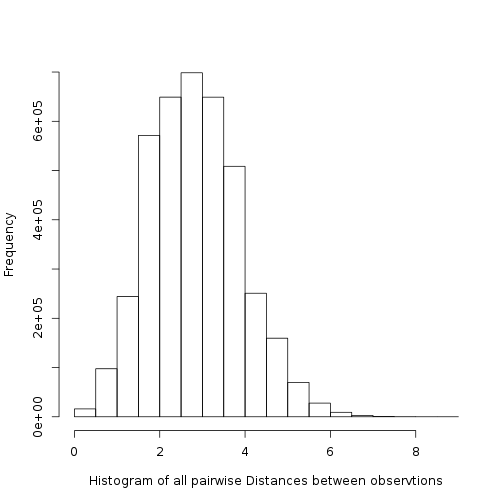

> Visualization is very important for data analytics, as it can provide a first understanding of the data.

#### Step 6. Select the clustering method to use and decide how many clusters to have

The hierarchical clustering method was used.

Seven clusters were decided upon. An iterative analysis process revealed the following:

1. The transition from six to seven clusters split an existing cluster into two new clusters. A qualitative analysis of the two clusters showed that they were both distinct and meaningful for marketing purposes.
2. The transition from seven to eight clusters introduced a new cluster that was relatively indistinct from an existing cluster. Therefore, eight segments was where the creation of unmeaningful clusters began.

In this note we will use two widely used methods: the **Kmeans Clustering Method**, and the **Hierarchical Clustering Method**. Like all clustering methods, these two also require that we have decided how to measure the distance/similarity between our observations. Explaining how these methods work is beyond our scope. The only difference to highlight is that Kmeans requires the user to define how many segments to create, while Hierarchical Clustering does not.

Let's fist use the **Hierarchial Clustering** method, as we do not know for now how many segments there are in our data. Hierarchical clustering is a method that also helps us visualise how the data may be clustering together. It generates a plot called the **Dendrogram** which is often helpful for visualization - but should be used with care. For example, in this case the dendrogram, using the euclidean distance metric from the earlier steps and the ward hierarchical clustering option (see below as well as help(hclust) in R for more information), is as follows:

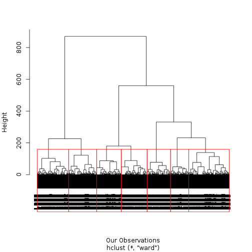

Note that we can draw as many clusters are we choose (e.g. in this case we chose 7 clusters) around the branches of the Dendrogram.

#### Step 7. Profile and interpret the clusters

After assessing the data we have arrived at 7 segments that Creeq can potentially target. We observed that when attempting to use 8 segments, the profiles of the clusters started to blend in with one another and the point of differentiation between some of them started to fade. In attempting to use 6 clusters, one of the clusters was clearly discernable into two segments.

We can also “visualize” the segments using **snake plots** for each cluster. For example, we can plot the means of the profiling variables for each of our clusters to better visualize differences between segments. For better visualization we plot the standardized profiling variables.

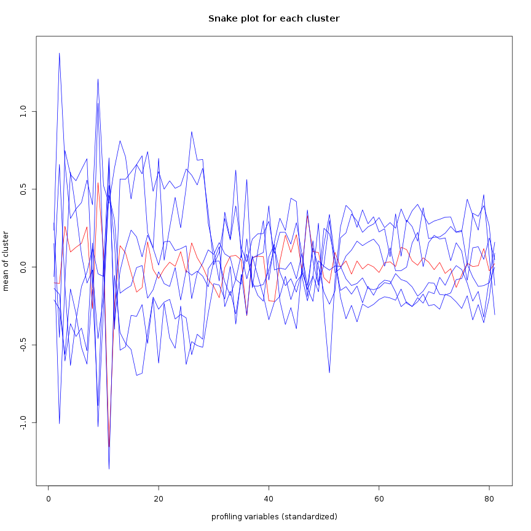

Can we see differences between the segments?

We can also compare the averages of the profiling variables of each segment relative to the average of the variables across the whole population. This can also help us better understand whether there are indeed clusters in our data (e.g. if all segments are much like the overall population, there may be no segments). For example, we can measure the ratios of the average for each cluster to the average of the population (e.g. avg(cluster)/avg(population)) and explore a matrix as the following one:

|  | Segment 1 | Segment 2 | Segment 3 | Segment 4 | Segment 5 | Segment 6 | Segment 7 |
| --- | --- | --- | --- | --- | --- | --- | --- |
| Q1_1_When buying a boat I do a lot of shopping around and visit multiple dealers | 0.9796 | 1.031 | 1.058 | 0.9573 | 0.9872 | 1.048 | 0.9724 |
| Q1_2_When buying a boat getting the lowest price is more important than the boat brand | 0.9628 | 0.6462 | 0.841 | 0.9059 | 1.232 | 1.483 | 0.9386 |
| Q1_3_The brand of boat I buy says a lot about who I am | 1.086 | 0.968 | 1.246 | 0.8157 | 0.9602 | 1.219 | 0.802 |
| Q1_4_I only consider buying a boat from a reputable brand | 1.02 | 1.129 | 1.125 | 0.9705 | 0.8666 | 1.066 | 0.9235 |
| Q1_5_I am willing to pay a premium for a brand with a reputation for high quality | 1.033 | 1.095 | 1.145 | 0.9221 | 0.9101 | 1.098 | 0.8835 |
| Q1_6_Owning a boat is a way of rewarding myself for my hard work | 1.032 | 1.017 | 1.131 | 0.8925 | 0.9739 | 1.086 | 0.9183 |
| Q1_7_Owning a boat gives me a sense of achievement | 1.063 | 0.9749 | 1.17 | 0.8477 | 0.9921 | 1.137 | 0.8685 |
| Q1_8_When buying a boat functionality is more important than style | 0.9414 | 0.996 | 0.97 | 0.9698 | 1.026 | 1.087 | 1.034 |
| Q1_9_I see my boat as a status symbol | 1.203 | 0.8286 | 1.393 | 0.6676 | 0.9838 | 1.451 | 0.6171 |
| Q1_10_When buying a boat I rely more on expert opinion than my own e g consumer reports salespeople | 1.028 | 0.9468 | 0.9972 | 1.011 | 0.9834 | 1.145 | 0.9297 |
| Q1_11_I tend to perform minor boat repairs and maintenance on my own | 0.6154 | 1.221 | 1.234 | 0.5679 | 1.154 | 1.136 | 1.175 |
| Q1_12_When it comes to boating I tend to prefer a basic boat with little to no frills | 0.9146 | 0.8745 | 0.8581 | 0.9814 | 1.106 | 1.226 | 1.056 |
| Q1_13_When buying a boat I tend to buy the latest and greatest | 1.045 | 0.9915 | 1.184 | 0.8633 | 0.9454 | 1.264 | 0.8265 |
| Q1_14_When buying accessories for my boat I tend to buy the latest and greatest | 1.027 | 1.036 | 1.169 | 0.8529 | 0.9576 | 1.212 | 0.8466 |
| Q1_15_I am serious about the technology on my boat | 0.9911 | 1.059 | 1.15 | 0.8697 | 0.9705 | 1.107 | 0.9236 |
| Q1_16_People tend to come to me for advice about boating | 0.9456 | 1.065 | 1.222 | 0.7652 | 0.9989 | 1.222 | 0.8932 |
| Q1_17_I consider myself more knowledgeable about boating than the rest of my boating peers | 0.9584 | 1.02 | 1.189 | 0.7843 | 1.003 | 1.226 | 0.924 |
| Q1_18_Boating gives me a feeling of adventure | 1.029 | 1.037 | 1.134 | 0.9243 | 0.9639 | 1.04 | 0.9113 |
| Q1_19_Boating allows me to experience nature | 0.9973 | 1.021 | 1.084 | 0.9651 | 0.9749 | 1.021 | 0.9669 |
| Q1_20_When not on my boat I often find myself doing boating related activities | 0.9776 | 1.004 | 1.189 | 0.8103 | 0.9908 | 1.215 | 0.9168 |
| Q1_21_Boating helps me escape from everyday life and relax | 0.9979 | 1.028 | 1.086 | 0.9602 | 0.9818 | 1.007 | 0.9615 |
| Q1_22_Boating helps me stay active | 1.006 | 1.031 | 1.102 | 0.9162 | 0.977 | 1.046 | 0.9618 |
| Q1_23_Boating allows me to excel in the sports that I am passionate about e g fishing racing water sports | 1.001 | 1.03 | 1.145 | 0.8501 | 0.9993 | 1.129 | 0.9041 |
| Q1_24_Boating gives me an outlet to socialize with family and or friends | 1.018 | 1.022 | 1.097 | 0.9539 | 0.9608 | 1.046 | 0.9439 |
| Q1_25_Being in charge of my boat is very important to me | 0.9911 | 1.033 | 1.152 | 0.8493 | 0.9945 | 1.123 | 0.9214 |
| Q1_26_Having a powerful boat is what is most important to me | 1.056 | 0.9274 | 1.21 | 0.8294 | 0.9814 | 1.31 | 0.7991 |
| Q1_27_Boating is the number one thing I do with my spare time | 1.02 | 0.9874 | 1.175 | 0.8323 | 0.9912 | 1.228 | 0.8566 |
| Q1_28_Boating is my true passion in life | 1.00 | 1.007 | 1.189 | 0.8469 | 0.9827 | 1.205 | 0.8623 |
| Q1_29_Boating is one of many things I do in my spare time | 0.9855 | 1.02 | 1.064 | 0.9459 | 0.977 | 1.051 | 0.998 |
| Q2_How many powerboats do you currently own | 0.8906 | 1.072 | 1.013 | 0.9067 | 1.033 | 1.093 | 1.036 |

[output cut: 51 more lines]

#### Step 8. Assess the robustness of our clusters

We will skip this step for this exercise. However in practice this is a very important step.

## Intepretation, Decisions and Conclusion

Based on the data and subsequent segment profiling, it would appear that CreeqBoat is positioned as a high-end brand in people's minds. Based on the segment profile analysis, it appears that those most likely to recommend or purchase CreeqBoat products are those that fall in the “Knowledgeable / Experienced Boaters” segment or in the “Power Status Seekers” segment. Those in the more price sensitive segments, such as young “Bang for Buck” respondents or “No Frills” respondents, were much less likely to highly consider CreeqBoat as a brand.

Those segments who were likely to recommend or purchase CreeqBoat products had certain key associations with the brand: trust, prestige, power, easy to maintain. These key associations seem to provide the justification to pay a higher price for CreeqBoat products. The brand seems to attract those who are looking for a brand they can be proud of owning. It is perhaps encouraging to note that the brand not only attracts older, autonomous and experienced boaters (connaisseurs) but also the younger, more power-hungry jet-setting consumer.

CreeqBoat must now decide if it wishes to remain positioned in the “high-end” brand segment or whether it wants to move more mass-market and cater to more price-sensitive consumers.

We would likely recommend that they capitalize on their brand equity in the “high-end” segment and concentrate marketing efforts on building up and maintaining the key brand associations (as explored above) that seem to attract the Experienced Boaters as well as the Power-Status Seekers. We would recommend not only clear marketing messages that reinforce this perception but also a continued commitment to quality in production (at the R&D and manufacturing level) in order to back up the brand equity.